# PalEON Summer Course: R module

## August 2016

## Chris Paciorek

In this module, we'll introduce R by way of working with some pollen data.

First, let's make sure we have the course materials on our computers. We can download the material from Github by setting up a project in RStudio.

Go to “File->New Project” and select “Version Control” and “Git”. Enter “https://github.com/PalEON-Project/Camp2016” as the “Repository URL” and click “Create Project” (you can choose the directory in which to place the project with the “Create project as subdirectory of” option). It should create a “Camp2016” directory with all of the materials within whichever directory you chose.

Or https://github.com/PalEON-Project/Camp2016/archive/master.zip.

# Reading in data

We can read in data using the read.table() function, of which `read.csv()` is a variant for reading in comma-delimited (CSV) files. `getwd()` and `setwd()` help us navigate the computer's directory structure. `read.fwf()` will read fixed-width format files.

```r
getwd()
```

```
## [1] "/var/tmp/paciorek/paleon/Camp2016/statsR"
```

```r
setwd('~/Desktop/Camp2016/statsR')
# platform independent code:
# setwd(file.path('~', 'Desktop', 'Camp2016', 'statsR'))

pollen <- read.csv('data/newEngland/modernPollen.csv')
ponds <- read.csv('data/newEngland/pondInfo.csv')
#help(read.csv)
#help(read.table)
names(pollen)
```

```
##  [1] "sitenumber" "sitename"   "BEECH"      "BIRCH"      "CHESTNUT"
##  [6] "HEMLOCK"    "HICKORY"    "MAPLE"      "OAK"        "PINE"
## [11] "SPRUCE"     "other"
```

```r
head(pollen)
```

```
##   sitenumber sitename BEECH BIRCH CHESTNUT HEMLOCK HICKORY MAPLE OAK  PINE
## 1          1     Aino    22   162        2      38       6    18 139  82.0
## 2          2   Benson    44   135        0      52      13    16  77  38.5
## 3          3  Berry W    28   167        4      26      19    16 140  53.0
## 4          4    Blood    15   132       15      16      22    13 169  69.0
## 5          5      Doe    16   113        2      18      10     5 209 104.0
## 6          6    Green    14   106       28      23       4    11 111  76.0
##   SPRUCE other
## 1   10.0    30
## 2    2.0    59
## 3    6.0    52
## 4    4.0    32
## 5    4.0    28
## 6    2.5    33
```

```r
class(pollen)
```

```
## [1] "data.frame"
```

# Interlude: operating at the command line

In R, as in Linux/UNIX, there are a number of tools that enhance your efficiency :

- The up and down arrows recall previous entries.
- Hitting `<tab>` attempts to complete the function or object name.
- `<Ctrl-k>` kills the remainder of the line from the cursor forward.
- `<Ctrl-a>` goes to the beginning of the line (`<Ctrl-e>` often goes to the end but apparently not in RStudio).

More generally, typing commands and saving your operations in text files (aka scripts), rather than point-and-click operations, allows you to reproduce your work, easily redo it and modify it, and share it with others.

# R objects

Everything in R is stored as an object, each of which has a class that describes what the object contains and standard functions that operate on objects in the class. The basic classes are

- *character* vectors: these are sets of character values (i.e., strings). Examples of character values are: “Sam”, “0923”, “Sam9”, “Sam is”, “Sam\t9”, “Sam's the man.\nNo doubt.\n”. Each of these is a character vector of length 1.
- *numeric* vectors (i.e., double precision real numbers)
- *integer* vectors
- *logical* (TRUE/FALSE) vectors
- *lists*: vectors of arbitrary objects
- *factors*: vector-like objects of categorical variables with a pre-defined set of labels
- *functions*

More complicated objects:

- Data frames can be thought of as a list of vectors of the same length, where the vectors may have different types.
- Matrices are different from data frames in that all the elements are of a single type. Furthermore, matrices and arrays (which allow dimensions of 1, 2, 3, ….) can be thought of as vectors with information on dimensions (layout). If you pass a matrix into a function expecting a vector, it will just treat it as a vector (of concatenated columns).

We can figure out what objects exist, as well as how much memory they take up, and we can remove them.

```r
class(pollen)
```

```
## [1] "data.frame"
```

```r
x <- c(7.3, 5, 11)
class(x)
```

```
## [1] "numeric"
```

```r
is.data.frame(x)
```

```
## [1] FALSE
```

```r
class(pollen$sitename)
```

```
## [1] "factor"
```

```r
pollen$sitename
```

```
##  [1] Aino           Benson         Berry W        Blood
##  [5] Doe            Green          Larkum         Lily NS
##  [9] Lily W         Little Bolton  Little Mirror  Little Royalst
## [13] North Round    North          Otter          Pecker
## [17] Pickerel       Quag           Silver         Snake
## [21] Uncas          Walden         Wickett        20
## [25] 88             992            993            1718
## [29] 1721           1723           3066           3067
## [33] 3303           3304           3305           3759
## [37] Red Mill       Beebe
## 38 Levels: 1718 1721 1723 20 3066 3067 3303 3304 3305 3759 88 992 ... Wickett
```

```r
as.character(pollen$sitename)
```

```
##  [1] "Aino"           "Benson"         "Berry W"        "Blood"
##  [5] "Doe"            "Green"          "Larkum"         "Lily NS"
##  [9] "Lily W"         "Little Bolton"  "Little Mirror"  "Little Royalst"
## [13] "North Round"    "North"          "Otter"          "Pecker"
## [17] "Pickerel"       "Quag"           "Silver"         "Snake"
## [21] "Uncas"          "Walden"         "Wickett"        "20"
## [25] "88"             "992"            "993"            "1718"
## [29] "1721"           "1723"           "3066"           "3067"
## [33] "3303"           "3304"           "3305"           "3759"
## [37] "Red Mill"       "Beebe"
```

```r
class(pollen$SPRUCE)
```

```
## [1] "numeric"
```

```r
object.size(x)
```

```
## 72 bytes
```

```r
x <- rnorm(10000000)
object.size(x)
```

```
## 80000040 bytes
```

```r
print(object.size(x), units = "Mb")
```

```
## 76.3 Mb
```

```r
# that code is a bit opaque and I'm lazy, so let's write our own function:
size <- function(x){
     print(object.size(x), units = "Mb")
}

size(x)
```

```
## 76.3 Mb
```

```r
ls()
```

```
## [1] "pollen" "ponds"  "size"   "x"
```

```r
rm(x)
ls()
```

```
## [1] "pollen" "ponds"  "size"
```

# Dataframe manipulation (and some plotting)

Let's demonstrate how we can manipulate data sets. First, let's get some information about our two datasets and merge them together.

```r
names(pollen)
```

```
##  [1] "sitenumber" "sitename"   "BEECH"      "BIRCH"      "CHESTNUT"
##  [6] "HEMLOCK"    "HICKORY"    "MAPLE"      "OAK"        "PINE"
## [11] "SPRUCE"     "other"
```

```r
class(names(pollen))
```

```
## [1] "character"
```

```r
names(pollen) <- tolower(names(pollen))
names(ponds) <- tolower(names(ponds))
cor(pollen$oak, pollen$spruce)
```

```
## [1] -0.4324522
```

```r
dim(pollen)
```

```
## [1] 38 12
```

```r
taxaCols <- 3:12
pollen$total <- rowSums(pollen[ , taxaCols])
pollen2 <- pollen
pollen2[ , taxaCols] <- pollen2[ , taxaCols] / pollen2$total # careful here: I know that R will divide each numerator column by the denominator column
head(pollen2)
```

```
##   sitenumber sitename      beech     birch    chestnut    hemlock
## 1          1     Aino 0.04322200 0.3182711 0.003929273 0.07465619
## 2          2   Benson 0.10080183 0.3092784 0.000000000 0.11912944
## 3          3  Berry W 0.05479452 0.3268102 0.007827789 0.05088063
## 4          4    Blood 0.03080082 0.2710472 0.030800821 0.03285421
## 5          5      Doe 0.03143418 0.2220039 0.003929273 0.03536346
## 6          6    Green 0.03427173 0.2594859 0.068543452 0.05630355
##       hickory       maple       oak      pine      spruce      other total
## 1 0.011787819 0.035363458 0.2730845 0.1611002 0.019646365 0.05893910 509.0
## 2 0.029782360 0.036655212 0.1764032 0.0882016 0.004581901 0.13516609 436.5
## 3 0.037181996 0.031311155 0.2739726 0.1037182 0.011741683 0.10176125 511.0
## 4 0.045174538 0.026694045 0.3470226 0.1416838 0.008213552 0.06570842 487.0
## 5 0.019646365 0.009823183 0.4106090 0.2043222 0.007858546 0.05500982 509.0
## 6 0.009791922 0.026927785 0.2717258 0.1860465 0.006119951 0.08078335 408.5
```

```r
full <- merge(ponds, pollen2, by.x = "site", by.y = "sitename", all.x = FALSE, all.y = TRUE)
head(full)
```

```
##   site id gridcell        x       y     lat      lon sitenumber      beech
## 1 1718 28      157 732230.2 4766978 43.0200 -72.1500         28 0.02919708
## 2 1721 29       63 661729.1 4793316 43.2753 -73.0069         29 0.08305648
## 3 1723 30      179 757270.4 4639990 41.8700 -71.9000         30 0.00418410
## 4   20 24      193 768487.8 4621267 41.6979 -71.7735         24 0.03045685
## 5 3066 31      134 722562.1 4686616 42.3000 -72.3000         31 0.01091703
## 6 3067 32      136 719390.6 4708748 42.5000 -72.3300         32 0.00000000
##       birch   chestnut    hemlock     hickory      maple       oak
## 1 0.3868613 0.01094891 0.04379562 0.000000000 0.02919708 0.1496350
## 2 0.3687708 0.00000000 0.16611296 0.009966777 0.05315615 0.1063123
## 3 0.2677824 0.02092050 0.00418410 0.046025105 0.01673640 0.4728033
## 4 0.2385787 0.02030457 0.01522843 0.040609137 0.01522843 0.4822335
## 5 0.3864629 0.00000000 0.01091703 0.032751092 0.03275109 0.3209607
## 6 0.4959786 0.00000000 0.04289544 0.010723861 0.02144772 0.2037534
##         pine     spruce      other total
## 1 0.20802920 0.05109489 0.09124088   274
## 2 0.08637874 0.01993355 0.10631229   301
## 3 0.11297071 0.01255230 0.04184100   239
## 4 0.12690355 0.00000000 0.03045685   197
## 5 0.12882096 0.00000000 0.07641921   458
## 6 0.13941019 0.01072386 0.07506702   373
```

```r
summary(full)
```

```
##       site          id           gridcell           x
##  1718   : 1   Min.   : 1.00   Min.   : 10.0   Min.   :628693
##  1721   : 1   1st Qu.:10.25   1st Qu.: 58.5   1st Qu.:661198
##  1723   : 1   Median :19.50   Median :123.0   Median :718244
##  20     : 1   Mean   :19.50   Mean   :119.6   Mean   :712410
##  3066   : 1   3rd Qu.:28.75   3rd Qu.:169.0   3rd Qu.:749465
##  3067   : 1   Max.   :38.00   Max.   :232.0   Max.   :801203
##  (Other):32
##        y                lat             lon           sitenumber
##  Min.   :4621267   Min.   :41.70   Min.   :-73.43   Min.   : 1.00
##  1st Qu.:4683904   1st Qu.:42.29   1st Qu.:-73.02   1st Qu.:10.25
##  Median :4710950   Median :42.52   Median :-72.34   Median :19.50
##  Mean   :4704657   Mean   :42.46   Mean   :-72.42   Mean   :19.50
##  3rd Qu.:4725148   3rd Qu.:42.65   3rd Qu.:-71.96   3rd Qu.:28.75
##  Max.   :4793316   Max.   :43.28   Max.   :-71.34   Max.   :38.00
##
##      beech             birch            chestnut           hemlock
##  Min.   :0.00000   Min.   :0.09514   Min.   :0.000000   Min.   :0.004184
##  1st Qu.:0.02873   1st Qu.:0.23731   1st Qu.:0.001946   1st Qu.:0.033482
##  Median :0.04237   Median :0.27378   Median :0.005603   Median :0.046681
##  Mean   :0.04898   Mean   :0.29829   Mean   :0.016314   Mean   :0.064015
##  3rd Qu.:0.06093   3rd Qu.:0.37137   3rd Qu.:0.019082   3rd Qu.:0.097286
##  Max.   :0.19692   Max.   :0.60928   Max.   :0.125320   Max.   :0.219178
##
##     hickory            maple               oak               pine
##  Min.   :0.00000   Min.   :0.003846   Min.   :0.06963   Min.   :0.06576
##  1st Qu.:0.01093   1st Qu.:0.020201   1st Qu.:0.17909   1st Qu.:0.10518
##  Median :0.01885   Median :0.030072   Median :0.27122   Median :0.12849
##  Mean   :0.02061   Mean   :0.029338   Mean   :0.28006   Mean   :0.15093
##  3rd Qu.:0.02958   3rd Qu.:0.035235   3rd Qu.:0.36185   3rd Qu.:0.18907
##  Max.   :0.04603   Max.   :0.060606   Max.   :0.55706   Max.   :0.32607
##
##      spruce             other             total
##  Min.   :0.000000   Min.   :0.03046   Min.   :113.0
##  1st Qu.:0.004006   1st Qu.:0.04738   1st Qu.:275.8
##  Median :0.008987   Median :0.06298   Median :471.0
##  Mean   :0.020259   Mean   :0.07120   Mean   :406.6
##  3rd Qu.:0.018618   3rd Qu.:0.08853   3rd Qu.:515.8
##  Max.   :0.131274   Max.   :0.20000   Max.   :584.0
##
```

```r
taxaCols <- 9:18
cor(full[ , taxaCols])
```

```
##                beech       birch     chestnut     hemlock     hickory
## beech     1.00000000  0.15336875 -0.086425336  0.74427087 -0.24362622
## birch     0.15336875  1.00000000 -0.093410002  0.21753148 -0.34024164
## chestnut -0.08642534 -0.09341000  1.000000000 -0.11692554  0.11046471
## hemlock   0.74427087  0.21753148 -0.116925536  1.00000000 -0.32608554
## hickory  -0.24362622 -0.34024164  0.110464711 -0.32608554  1.00000000
## maple     0.33391300  0.06704972 -0.058152385  0.26405489 -0.31207561
## oak      -0.55114123 -0.70933481  0.003130577 -0.68103038  0.44571068
## pine     -0.31939009 -0.54238669 -0.142772222 -0.19392440 -0.04325970
## spruce    0.28925229  0.42990179 -0.009222915  0.18773336 -0.18490984
## other    -0.11865829  0.05381028  0.018237575  0.07200185 -0.06926445
##                maple          oak       pine       spruce       other
## beech     0.33391300 -0.551141228 -0.3193901  0.289252287 -0.11865829
## birch     0.06704972 -0.709334813 -0.5423867  0.429901794  0.05381028
## chestnut -0.05815239  0.003130577 -0.1427722 -0.009222915  0.01823758
## hemlock   0.26405489 -0.681030382 -0.1939244  0.187733359  0.07200185
## hickory  -0.31207561  0.445710680 -0.0432597 -0.184909843 -0.06926445
## maple     1.00000000 -0.254288261 -0.3356794  0.016627720  0.45234243
## oak      -0.25428826  1.000000000  0.2712086 -0.569148340 -0.25055263
## pine     -0.33567935  0.271208636  1.0000000 -0.276443539 -0.15581558
## spruce    0.01662772 -0.569148340 -0.2764435  1.000000000  0.01918649
## other     0.45234243 -0.250552627 -0.1558156  0.019186486  1.00000000
```

```r
library(fields, quietly = TRUE)
```

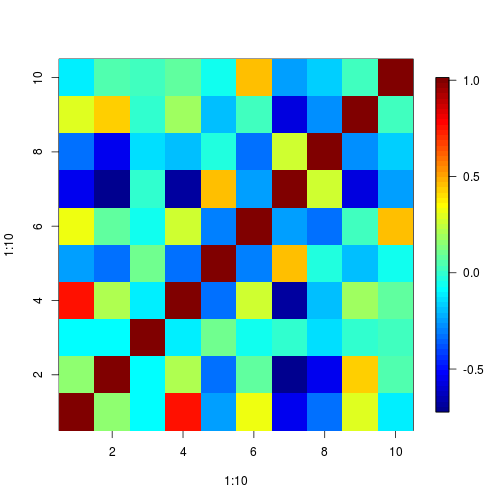

```r
image.plot(1:10, 1:10, cor(full[ , taxaCols])) # I should change the z-scale and the color scheme
```

Now let's make some basic plots.

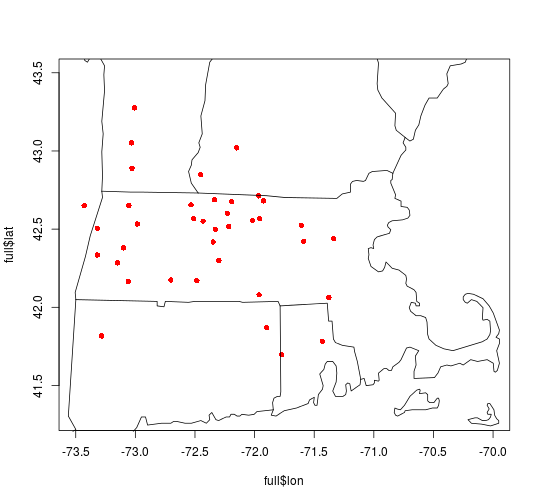

```r
library(maps)
plot(full$lon, full$lat, xlim = c(-73.5, -70), ylim = c(41.3,43.5), col = 'red', pch = 16)
map('state', add = TRUE)
```

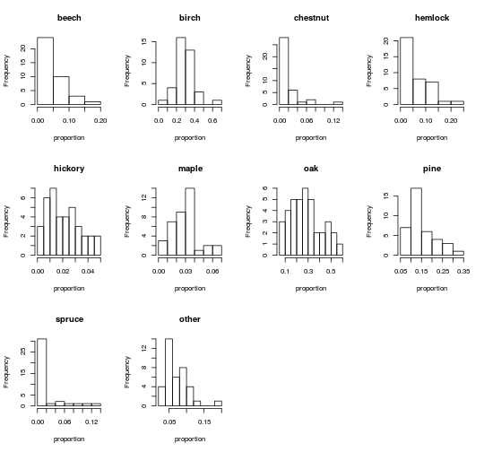

```r
par(mfrow=c(3,4))
for(i in taxaCols){
  hist(full[ , i], main = names(full)[i], xlab = "proportion")
}
```

**Challenge**: make a single plot that shows side-by-side boxplots of the proportions for each species. Find out what input formats the `boxplot()` function can handle. Manipulate the arguments to make your figure presentable.

# More on indexing and subsetting

Now let's see some different ways to select subsets and use indexing. Often there are multiple ways to do things in R. Some are more efficient than others, which only really becomes an issue when working with large objects.

```r
sub <- full[1:5, ]
full$lon < (-72.5)
```

```
##  [1] FALSE  TRUE FALSE FALSE FALSE FALSE  TRUE  TRUE  TRUE FALSE FALSE
## [12]  TRUE  TRUE FALSE  TRUE  TRUE  TRUE FALSE  TRUE  TRUE  TRUE FALSE
## [23] FALSE FALSE FALSE FALSE  TRUE FALSE  TRUE FALSE FALSE FALSE  TRUE
## [34] FALSE FALSE FALSE FALSE FALSE
```

```r
west <- full[full$lon < -72.5, ]
full[full$lon < -72.5, c("oak", "pine")]
```

```
##           oak       pine
## 2  0.10631229 0.08637874
## 7  0.23843416 0.24911032
## 8  0.10619469 0.09734513
## 9  0.26046512 0.13953488
## 12 0.30690537 0.10485934
## 13 0.14393939 0.10227273
## 15 0.07528958 0.07142857
## 16 0.17640321 0.08820160
## 17 0.27397260 0.10371820
## 19 0.41060904 0.20432220
## 20 0.27172583 0.18604651
## 21 0.24173554 0.12603306
## 27 0.09417808 0.09417808
## 29 0.27075812 0.12815884
## 33 0.06963250 0.06576402
```

```r
indices <- which(full$lon < -72.5)
indices
```

```
##  [1]  2  7  8  9 12 13 15 16 17 19 20 21 27 29 33
```

```r
full[indices, c(15,16)]
```

```
##           oak       pine
## 2  0.10631229 0.08637874
## 7  0.23843416 0.24911032
## 8  0.10619469 0.09734513
## 9  0.26046512 0.13953488
## 12 0.30690537 0.10485934
## 13 0.14393939 0.10227273
## 15 0.07528958 0.07142857
## 16 0.17640321 0.08820160
## 17 0.27397260 0.10371820
## 19 0.41060904 0.20432220
## 20 0.27172583 0.18604651
## 21 0.24173554 0.12603306
## 27 0.09417808 0.09417808
## 29 0.27075812 0.12815884
## 33 0.06963250 0.06576402
```

```r
west2 <- subset(full, lon < -72.5, select = c("oak", "pine"))
```

**Challenge**: extract the even rows of the full dataset. Consider the `rep()` and `seq()` functions.

R does not provide a built-in function for sorting data frames.

```r
full <- full[order(full$lat, full$lon), ]
head(full)[ , 1:8]
```

```
##     site id gridcell        x       y      lat       lon sitenumber
## 4     20 24      193 768487.8 4621267 41.69790 -71.77350         24
## 11    88 25      226 796433.7 4631836 41.78300 -71.43300         25
## 12   992 26       18 642607.0 4630883 41.81700 -73.28300         26
## 3   1723 30      179 757270.4 4639990 41.87000 -71.90000         30
## 36 Uncas 21      229 799751.4 4663087 42.06267 -71.37728         21
## 18 Blood  4      165 751296.7 4663126 42.08000 -71.96200          4
```

That's a bit frustrating but easily fixable once we talk more about writing functions. (Also see `arrange()` in the `dplry` or `plyr` packages.)

# Vectorized operations and the apply function

Many R functions operate on vectors without having to loop over the indices, and in fact vectorized operations are generally much faster than using a loop.

```r
log(full$oak)
```

```
##  [1] -0.7293268 -0.6034184 -1.1812158 -0.7490757 -0.6849167 -1.0583654
##  [7] -1.4199110 -0.9066288 -0.8901138 -1.4336620 -1.1364366 -1.3452863
## [13] -1.7349830 -1.1182593 -1.0029512 -0.7854885 -1.5908451 -1.2947272
## [19] -1.6486586 -0.5850824 -2.2424812 -1.1087236 -1.4319825 -1.3029617
## [25] -1.5099083 -0.9298350 -1.9383629 -2.3625678 -1.3065294 -1.7297678
## [31] -1.2979741 -1.7144758 -1.3031440 -1.7216499 -2.6645239 -1.8995560
## [37] -2.5864136 -2.2413744
```

```r
full$coldSpp <- full$beech + full$hemlock + full$spruce
full$west <- full$lon < -72.5
full$north <- full$lat > 42.5
full$north <- FALSE # example of recyling
full$north[full$lat > 42.5] <- TRUE
full$nw <- full$west & full$north
round(full$lat, digits = 1)
```

```
##  [1] 41.7 41.8 41.8 41.9 42.1 42.1 42.2 42.2 42.2 42.3 42.3 42.3 42.4 42.4
## [15] 42.4 42.4 42.5 42.5 42.5 42.5 42.5 42.6 42.6 42.6 42.6 42.6 42.6 42.7
## [29] 42.7 42.7 42.7 42.7 42.7 42.8 42.9 43.0 43.1 43.3
```

Useful commands are `with()` and `within()`, which allow you to avoid a bunch of typing. The basic idea is to do a bunch of stuff all within a certain context.

```r
full <- within(full, warmSpp <- oak + hickory)
full$warmSpp[1:8]
```

```
## [1] 0.5228426 0.5755102 0.3401535 0.5188285 0.5454545 0.3921971 0.2561983
## [8] 0.4407767
```

`dplyr` is a nice additional package that allows you to do this sort of thing quite easily.

R has a feature called recycling by which it will fill in additional entries in vectors, matrices, data frames:

```r
mat <- matrix(1:2, nrow = 4, ncol = 4) # what do you think will happen?
mat <- matrix(1:3, nrow = 4, ncol = 4)
```

One useful type of data structure in R is a list. A list is a vector of potentially unrelated items. Lists are commonly used as the output from functions.

```r
myList <- list(a = 7, b = c(8, 9, 11), d = "wtfit?", e = list(first = 7,
 second = 8))
myList$b
```

```
## [1]  8  9 11
```

```r
myList[[2]]
```

```
## [1]  8  9 11
```

```r
myList$e$first
```

```
## [1] 7
```

```r
is.list(full)
```

```
## [1] TRUE
```

```r
myModel = lm(spruce ~ lat, data = full)
is.list(myModel)
```

```
## [1] TRUE
```

```r
names(myModel)
```

```
##  [1] "coefficients"  "residuals"     "effects"       "rank"
##  [5] "fitted.values" "assign"        "qr"            "df.residual"
##  [9] "xlevels"       "call"          "terms"         "model"
```

```r
myModel$coefficients
```

```
## (Intercept)         lat
## -1.49783322  0.03575035
```

We can use `lapply()` “apply” an arbitrary function to each element of the list. This is easier to write (though not necessarily faster) than using a loop.

```r
myList = list(1:3, 4:8, 101, 111:150)
lapply(myList, max) # vs.
```

```
## [[1]]
## [1] 3
##
## [[2]]
## [1] 8
##
## [[3]]
## [1] 101
##
## [[4]]
## [1] 150
```

```r
out = rep(NA, length(myList))
for(i in 1:length(myList))
   out[i] <- max(myList[[i]])
```

**Challenge**: how can I find the median abundance of each species across all the ponds? Hint, treating a subset of the columns of the `full` dataframe as if they were a list will work.

# Functions

We've already seen a bit of functions: we wrote our own little function and we've used lots of functions from the core R software and additional packages.

Functions allow one to modularize their code and are at the core of good programming.

Let's create a function to plot the proportion of a given taxon on a map. Once we we've done this, we can use the function on each taxon to create one map per taxon.

First, we'll prototype the code for a single taxon.

What do we need to decide in terms of what our function is going to do, what its arguments should be, and what steps the function should carry out?

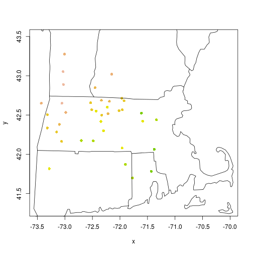

```r
library(maps)
x <- full$lon
y <- full$lat
z <- full$oak
propBreaks = c(0, 0.01, 0.05, 0.10, 0.15, 0.2, 0.3, 0.4, 0.5, 0.6, 0.8, 1)
colors <- rev(terrain.colors(length(propBreaks)))
cats <- cut(z, breaks = propBreaks)
cats <- as.integer(cats)
plot(x, y, xlim = c(-73.5, -70), ylim = c(41.3, 43.5), col = colors[cats], pch = 16)
map("state", add = TRUE)
```

Now let's work through how we would make a function out of this.

# Plotting bells and whistles

Let's take our previous plots and gussy them up for the ball, or at least fit for a trip into the village.

Note that more recent R packages provide more visually-appealing graphics and more elegant syntax, in particular the `ggplot2` package. We'll likely see more of that later this week.

```r
pdf('treeComp.pdf', height = 4, width = 7)
par(mfrow = c(2,5), mai = c(.25,.25,.3,.1), omi = c(.3, .3, .4, 0))
for(i in taxaCols)
      hist(full[ , i], xlim = c(0, 1), xlab = '', ylab = '', main = names(full)[i])
title(ylab = 'frequency', outer = TRUE, line = 1, cex.lab = 1.5)
title(xlab = 'proportion of pollen', outer = TRUE, line = 1, cex.lab = 1.5)
title(main = paste('Pollen composition of ', nrow(full), ' ponds in New England', sep = ''),
     outer = TRUE, line = 1, cex.main = 1.5)
dev.off()
```

```r
#help(par)
par()$mfrow
```

```
## [1] 1 1
```

**On your own**: Take a look at the sort of graphics that R can create by invoking `demo(graphics)`, `demo(persp)`, `demo(image)`.

# Packages and loading data from other software

As part of preparing for the course, you've probably already downloaded and installed an R package from the R archive, CRAN. Packages provide additional functionality and are the “killer app” of R (think the App Store for Apple's iPhone). The packages are contributed by users and R developers and vary in quality. They implement most statistical algorithms (and other algorithms and utilities) that now exist. So if you're about to code something, it's worth checking to see if it's already been done. And if you develop or implement a new method, consider contributing it to CRAN as a package.

A useful place to look for answers to questions, find out about functionality and pose questions is the [R mailing list and its archive](http://tolstoy.newcastle.edu.au/R/). If you do post, follow the guidelines and provide enough information about the issue for those reading the list to be able to understand the question and reproduce any problems.

One very useful package is the `foreign` package, which contains interfaces that can read and write data formats for SAS, Stata, DBF, etc. For those who use netCDF and HDF files, there are packages that deal with those too (*ncdf4* in the case of netCDF).

```r
library(foreign)
#library(help = foreign)
```

# Finishing up

You can save your code in text files and read it all in at once, using `source()`: e.g.,

```r
source('silly.R')
```

```
## This is a file of useless R code.
## [1] 8
```

You can save some or all of your objects in a compressed R data file and load the objects back into R on any operating system, regardless of the system used to create the file.

```r
save(full, pollen, ponds, file = 'pollenAnalData.Rda')
# save.image('pollenFullAnal.Rda')
rm(list = ls())
ls()
```

```
## character(0)
```

```r
load('pollenAnalData.Rda')
ls()
```

```
## [1] "full"   "pollen" "ponds"
```

You can write out CSV and other delimited files with `write.table()` and `write.csv()`.